# The apply Functions in R: apply, lapply, sapply, vapply, tapply and split

## Recombining results: `do.call(rbind, ...)` and `unsplit()`

```r
# Summary data frame per group
summ <- lapply(split(cars, cars$cyl_f), function(d) {
  data.frame(cyl = unique(d$cyl), n = nrow(d),
             mean_mpg = mean(d$mpg), mean_hp = mean(d$hp))
})
summary_df <- do.call(rbind, summ)
rownames(summary_df) <- NULL
summary_df
```

```
##   cyl  n mean_mpg   mean_hp
## 1   4 11 26.66364  82.63636
## 2   6  7 19.74286 122.28571
## 3   8 14 15.10000 209.21429
```

```r
# Group-wise standardisation: z-score of mpg *within* each cylinder group,
# then put the values back in the original row order with unsplit()
z_within <- lapply(split(cars$mpg, cars$cyl_f), function(x) (x - mean(x)) / sd(x))
cars$mpg_z_within_cyl <- unsplit(z_within, cars$cyl_f)

head(cars[, c("cyl", "mpg", "mpg_z_within_cyl")])
```

```
##                   cyl  mpg mpg_z_within_cyl
## Mazda RX4           6 21.0        0.8648675
## Mazda RX4 Wag       6 21.0        0.8648675
## Datsun 710          4 22.8       -0.8567149
## Hornet 4 Drive      6 21.4        1.1400526
## Hornet Sportabout   8 18.7        1.4062236
## Valiant             6 18.1       -1.1302245
```

## Using `split()` on iris

```r
iris_split <- split(iris[, 1:4], iris$Species)
lapply(iris_split, colMeans)
```

```
## $setosa
## Sepal.Length  Sepal.Width Petal.Length  Petal.Width
##        5.006        3.428        1.462        0.246
##
## $versicolor
## Sepal.Length  Sepal.Width Petal.Length  Petal.Width
##        5.936        2.770        4.260        1.326
##
## $virginica
## Sepal.Length  Sepal.Width Petal.Length  Petal.Width
##        6.588        2.974        5.552        2.026
```

```r
# Tidy into a matrix: species in columns
sapply(iris_split, colMeans)
```

```
##              setosa versicolor virginica
## Sepal.Length  5.006      5.936     6.588
## Sepal.Width   3.428      2.770     2.974
## Petal.Length  1.462      4.260     5.552
## Petal.Width   0.246      1.326     2.026
```

# `tapply()` — apply a function by group

## Syntax

```r
tapply(X, INDEX, FUN, ..., default = NA, simplify = TRUE)
```

- `X` – a **vector** (one variable).
- `INDEX` – a factor, or a **list of factors**, the same length as `X`.
- `FUN` – function applied to the values of `X` in each group.

`tapply(X, INDEX, FUN)` is essentially `sapply(split(X, INDEX), FUN)`, but it returns an array whose dimensions correspond to the factors.

## One grouping factor

```r
tapply(cars$mpg, cars$cyl_f, mean)
```

```
##        4        6        8
## 26.66364 19.74286 15.10000
```

```r
tapply(cars$mpg, cars$cyl_f, sd)
```

```
##        4        6        8
## 4.509828 1.453567 2.560048
```

```r
tapply(cars$hp,  cars$am_f,  median)
```

```
## Automatic    Manual
##       175       109
```

```r
# Same result as split + sapply
sapply(split(cars$mpg, cars$cyl_f), mean)
```

```
##        4        6        8
## 26.66364 19.74286 15.10000
```

## Two grouping factors → a two-way table

```r
tapply(cars$mpg, list(Cylinders = cars$cyl_f, Transmission = cars$am_f), mean)
```

```
##          Transmission
## Cylinders Automatic   Manual
##         4    22.900 28.07500
##         6    19.125 20.56667
##         8    15.050 15.40000
```

```r
tapply(cars$mpg, list(cars$cyl_f, cars$am_f), mean, default = 0)
```

```
##   Automatic   Manual
## 4    22.900 28.07500
## 6    19.125 20.56667
## 8    15.050 15.40000
```

```r
# Count the observations in each cell to see where the gaps are
tapply(cars$mpg, list(cars$cyl_f, cars$am_f), length)
```

```
##   Automatic Manual
## 4         3      8
## 6         4      3
## 8        12      2
```

## Three factors → a three-dimensional array

```r
tapply(cars$mpg, list(cars$cyl_f, cars$am_f, cars$gear_f), mean)
```

```
## , , 3
##
##   Automatic Manual
## 4     21.50     NA
## 6     19.75     NA
## 8     15.05     NA
##
## , , 4
##
##   Automatic   Manual
## 4      23.6 28.03333
## 6      18.5 21.00000
## 8        NA       NA
##
## , , 5
##
##   Automatic Manual
## 4        NA   28.2
## 6        NA   19.7
## 8        NA   15.4
```

## Extra arguments

```r
# na.rm is passed on to mean()
mpg_na <- cars$mpg
mpg_na[c(1, 7, 15)] <- NA

tapply(mpg_na, cars$cyl_f, mean)                # NAs propagate
```

```
##        4        6        8
## 26.66364       NA       NA
```

```r
tapply(mpg_na, cars$cyl_f, mean, na.rm = TRUE)  # handled
```

```
##        4        6        8
## 26.66364 19.53333 15.55833
```

## Functions returning multiple values

When `FUN` returns a vector, `tapply()` returns a **list-array** (not a matrix). Convert it with `do.call(rbind, ...)`:

```r
res <- tapply(cars$mpg, cars$cyl_f,
              function(x) c(mean = mean(x), sd = sd(x), n = length(x)))
res                      # a 1-D list-array
```

```
## $`4`
##      mean        sd         n
## 26.663636  4.509828 11.000000
##
## $`6`
##      mean        sd         n
## 19.742857  1.453567  7.000000
##
## $`8`
##      mean        sd         n
## 15.100000  2.560048 14.000000
```

```r
do.call(rbind, res)      # a tidy matrix
```

```
##       mean       sd  n
## 4 26.66364 4.509828 11
## 6 19.74286 1.453567  7
## 8 15.10000 2.560048 14
```

## Plotting `tapply()` output

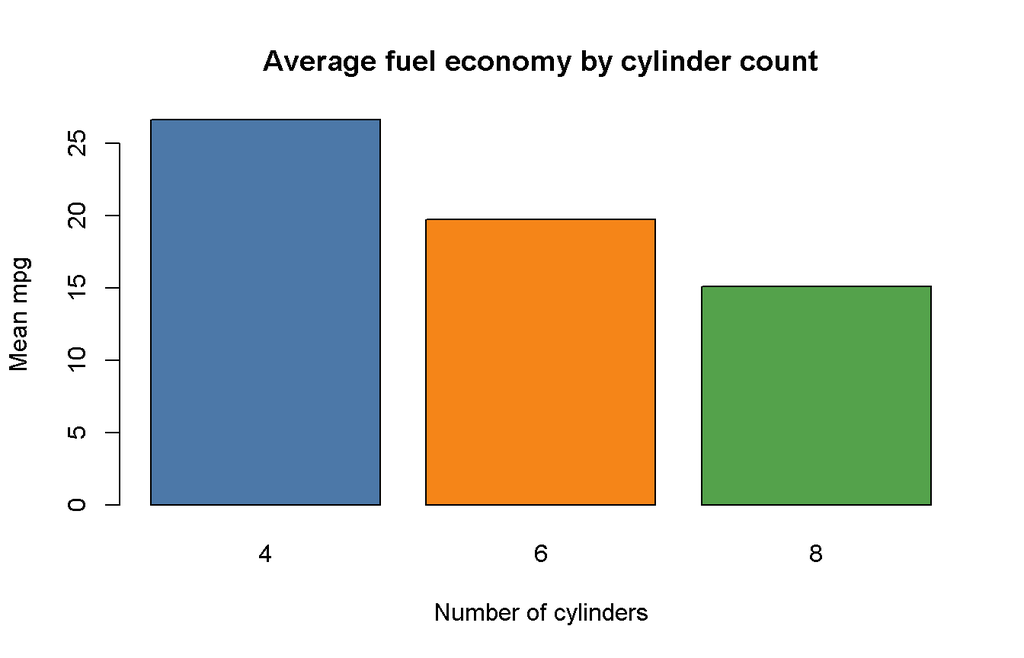

```r
avg <- tapply(cars$mpg, cars$cyl_f, mean)
barplot(avg, col = c("#4C78A8", "#F58518", "#54A24B"),
        xlab = "Number of cylinders", ylab = "Mean mpg",
        main = "Average fuel economy by cylinder count")
```

# Putting it together: a full workflow

**Question:** For each cylinder group and transmission type, what is the average mpg, which group is most fuel efficient, and how does each car compare with its own group’s average?

```r
# 1. tapply: quick two-way table of means
means_tbl <- tapply(cars$mpg, list(cars$cyl_f, cars$am_f), mean)
round(means_tbl, 2)
```

```
##   Automatic Manual
## 4     22.90  28.08
## 6     19.12  20.57
## 8     15.05  15.40
```

```r
# 2. split: one data frame per (cyl, transmission) combination that exists
groups <- split(cars, list(cars$cyl_f, cars$am_f), drop = TRUE)

# 3. vapply: safe numeric summaries for each group
summary_mat <- vapply(groups, function(d) c(n = nrow(d),
                                            mean_mpg = mean(d$mpg),
                                            mean_hp  = mean(d$hp),
                                            mean_wt  = mean(d$wt)),
                      FUN.VALUE = numeric(4))
round(t(summary_mat), 2)
```

```
##              n mean_mpg mean_hp mean_wt
## 4.Automatic  3    22.90   84.67    2.94
## 6.Automatic  4    19.12  115.25    3.39
## 8.Automatic 12    15.05  194.17    4.10
## 4.Manual     8    28.08   81.88    2.04
## 6.Manual     3    20.57  131.67    2.76
## 8.Manual     2    15.40  299.50    3.37
```

```r
# 4. Best group
best <- names(which.max(summary_mat["mean_mpg", ]))
cat("Most fuel-efficient group (cyl.transmission):", best, "\n")
```

```
## Most fuel-efficient group (cyl.transmission): 4.Manual
```

```r
# 5. lapply + unsplit: each car's mpg relative to its group's mean
rel <- lapply(groups, function(d) d$mpg - mean(d$mpg))
cars$mpg_vs_group <- unsplit(rel, list(cars$cyl_f, cars$am_f), drop = TRUE)
head(cars[, c("cyl", "am_f", "mpg", "mpg_vs_group")])
```

```
##                   cyl      am_f  mpg mpg_vs_group
## Mazda RX4           6    Manual 21.0    0.4333333
## Mazda RX4 Wag       6    Manual 21.0    0.4333333
## Datsun 710          4    Manual 22.8   -5.2750000
## Hornet 4 Drive      6 Automatic 21.4    2.2750000
## Hornet Sportabout   8 Automatic 18.7    3.6500000
## Valiant             6 Automatic 18.1   -1.0250000
```

```r
# 6. apply: summarise the numeric columns row-wise (a per-car "performance index")
perf <- apply(scale(cars[, c("mpg", "hp", "wt")]), 1,
              function(r) r["mpg"] - r["wt"] + 0.5 * r["hp"])
head(round(perf, 2))
```

```
##         Mazda RX4     Mazda RX4 Wag        Datsun 710    Hornet 4 Drive
##              0.49              0.23              0.98             -0.05
## Hornet Sportabout           Valiant
##             -0.25             -0.88
```

# Comparison and choosing the right function

```r
# The same task (column means) with every relevant function
a <- apply(num, 2, mean)                       # matrix-oriented
l <- unlist(lapply(num, mean))                 # list, then flatten
s <- sapply(num, mean)                         # simplified
v <- vapply(num, mean, numeric(1))             # type-safe

all.equal(a, l); all.equal(a, s); all.equal(a, v)
```

```
## [1] TRUE
```

```
## [1] TRUE
```

```
## [1] TRUE
```